# Introduction to Data Analysis with Python

*T.J. Langford*  
*Vincent Balbarin*  
*Yale Center for Reasearch Computing*  
*October 25, 2022*

# Overview

- Introduction to [Jupiter Docker Stacks](https://jupyter-docker-stacks.readthedocs.io/en/latest/)
- Introduction to [podman](https://podman.io/)
- Introduction to `numpy` and `matplotlib`
- Data processing and analysis with `numpy`
- Data visualization with `matplotlib`
- Real-world example of data processing

# Tutorial Requirements

- Repository for this tutorial: https://github.com/WrightLaboratory/data_analysis
  - Notebook
  - Test data
  - Supporting scripts
- `jupyter/scipy-notebook` Docker image
- Podman

# Jupyter and Docker

- The Jupyter project provides provides pre-built Docker images at [Jupyter Docker Stacks](https://jupyter-docker-stacks.readthedocs.io/en/latest/)
- No need to install and configure Python virtual environments
- [`jupiter/scipy-notebook`](https://jupyter-docker-stacks.readthedocs.io/en/latest/using/selecting.html#jupyter-scipy-notebook) image includes popular packages from the scientific Python ecosystem

# Podman

- Container engine for executing Open Container Initiative (OCI) compliant images
- `podman` cli supports many of the same flags as `docker` cli
- Available in Linux package repositories, podman machine running on a WSL VM in Windows, and podman machine running on QEMU VM in MacOS

# Podman Security

- Daemon-less and capable of running rootless
- Integrates with systemd
- Kubernetes-like
  - Related application components are grouped into pods
  - Namespaces provide another layer of isolation

# Running This Notebook

Follow the instructions to install Podman on your operating system of choice.

```
# Clone the repository
git clone https://github.com/WrightLaboratory/data_analysis data_analysis
```

```
# Use the provided script to launch Jupyter container
cd data_analysis
bash ./scripts/podman_jupyterlab.sh
```

```
# Find the url in the standard output log trace and open in your browser
...
[C 2022-10-18 03:30:26.665 ServerApp]

  To access the server, open this file in a browser:
      file:///home/jovyan/.local/share/jupyter/runtime/jpserver-2-open.html
```

```
Or copy and paste one of these URLs:
      http://784772c24b81:8888/lab?token=929d6fbdc29185ba5ac86b60c689e84b1f3fa2eb22b46ebc
```

```
or http://127.0.0.1:8888/lab?token=929d6fbdc29185ba5ac86b60c689e84b1f3fa2eb22b46ebc
...
```

# Data Processing with `numpy`

```python
import numpy as np
```

# What is Numpy?

NumPy is the fundamental package for scientific computing with Python. It contains among other things:

- a powerful N-dimensional array object
- sophisticated (broadcasting) functions
- tools for integrating C/C++ and Fortran code
- useful linear algebra, Fourier transform, and random number capabilities

[User Guide](https://docs.scipy.org/doc/numpy-1.16.1/)

## N-dimensional array objects

- Fundamental basis of numpy is the `array` object
- 1D array ~ vector
- 2D array ~ matrix
- nD array (n > 2) ~ tensor

### Creating arrays

Arrays can be created in a variety of ways. The most common are either empty:

```python
a = np.zeros(10)
a
```

```
array([0., 0., 0., 0., 0., 0., 0., 0., 0., 0.])
```

or you can create them from an existing `list`:

```python
b = np.array([0,1,2,3,4,5,6,7,8,9])
b
```

```
array([0, 1, 2, 3, 4, 5, 6, 7, 8, 9])
```

### Array properties

Arrays have a few key properties:

- Data type (float, int, etc)
- Number of dimensions
- Shape and Size

```python
print(a.dtype)
print(b.dtype)
```

```
float64
int64
```

```python
a.shape
```

```
(10,)
```

```python
c = np.array([[0,1,2,3],[4,5,6,7]])
c
```

```
array([[0, 1, 2, 3],
       [4, 5, 6, 7]])
```

### Array operations

We can also act on these arrays with specific operations:

- add, subtract, multiply, and divide by scalars or other arrays

```python
a = np.multiply(b, 4)
a
```

```
array([ 0,  4,  8, 12, 16, 20, 24, 28, 32, 36])
```

```python
np.multiply(a, b)
```

```
array([  0,   4,  16,  36,  64, 100, 144, 196, 256, 324])
```

- extract statistics about the array (minimum, maximum, RMS, etc)

```python
np.max(b)
```

```
9
```

```python
np.mean(a)
```

```
18.0
```

```python
np.std(a)
```

```
11.489125293076057
```

- sum array elements along an axis:

```python
np.sum(c, axis=0)
```

```
array([ 4,  6,  8, 10])
```

### Filter based on values

Array elements can be selected based on their values (or values of different arrays)

```python
print(a)
```

```
[ 0  4  8 12 16 20 24 28 32 36]
```

```python
a > 5
```

```
array([False, False,  True,  True,  True,  True,  True,  True,  True,
        True])
```

This array of `True`/`False` values can then filter either `a` or other arrays:

```python
a[a > 5]
```

```
array([ 8, 12, 16, 20, 24, 28, 32, 36])
```

```python
b[a > 5]
```

```
array([2, 3, 4, 5, 6, 7, 8, 9])
```

We will use this to filter some real data later in the tutorial.

### Import and Export Arrays

Numpy has two main ways of exporting and importing data:

- Saving human-readable text file with `np.savetxt`:

```python
np.savetxt('test.txt', c, fmt='%f', delimiter=',', header='My favorite array')
```

```python
cat test.txt
```

```
# My favorite array
0.000000,1.000000,2.000000,3.000000
4.000000,5.000000,6.000000,7.000000
```

- faster, more efficient numpy binary data (`test.npy`):

```python
np.save('test.npy', c)
```

- Reading text or binary data with `np.loadtxt` or `np.fromfile`

```python
np.loadtxt('test.txt',delimiter=',')
```

```
array([[0., 1., 2., 3.],
       [4., 5., 6., 7.]])
```

- `Numpy` and `pandas` also provide a variety of tools to read specific data formats (csv, binary, etc.)

## Random Number Generation with `numpy`

Numpy has a full suite of tools for generating random numbers. Very helpful for Monte Carlo simulations or toy data.

Here we will generate 100k random floats from a normal distribution with `mean = 2.0` and `sigma = 1.0`.

```python
r = np.random.normal(loc=2, scale=1, size=100000)
print(r[0:10])
```

```
[4.59294897 3.15374283 3.04135266 1.28198312 2.19810513 1.51165547
 1.75905533 2.94476109 1.28497692 1.17879256]
```

We can randomly select elements from an array:

```python
np.random.choice(a, size=2)
```

```
array([24, 32])
```

All the "heavy-lifting" is done in `C`, so `numpy`-based work can be *very* fast.

### Random Number Example: Monte Carlo $\pi$

We can perform a Monte Carlo-based simulation to calculate $\pi$ using two uniform random number generators.

```python
def mc_pi(num_trials):
    x = np.random.uniform(low=0.0, high=1.0, size=num_trials)
    y = np.random.uniform(low=0.0, high=1.0, size=num_trials)

    r = x**2 + y**2

    return len(r[r<1])*4/num_trials
```

```python
for n in [10,100,1000,10000,100000,1000000,10000000]:
    print(f"{n}: {mc_pi(n)}")
```

```
10: 3.2
100: 3.16
1000: 3.028
10000: 3.1464
100000: 3.13692
1000000: 3.142888
10000000: 3.1423868
```

## Plotting with Matplotlib

```python
import matplotlib.pyplot as plt
```

## Plotting with Matplotlib

- Matplotlib is the back-bone of most python plotting and visualization
- It's super flexible and produces both interactive and publication-ready plots
- We'll touch on a few examples to demonstrate the versitility of this module

## Basic 2D Plot

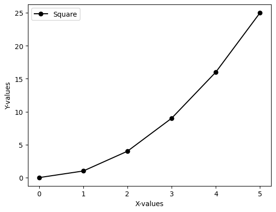

```python
x = np.array([0,1,2,3,4,5])
y = np.power(x, 2)
plt.plot(x, y, marker='o', color='k', label='Square');
plt.xlabel('X-values');
plt.ylabel('Y-values');
plt.legend(loc=2);
```

## Scatter plot

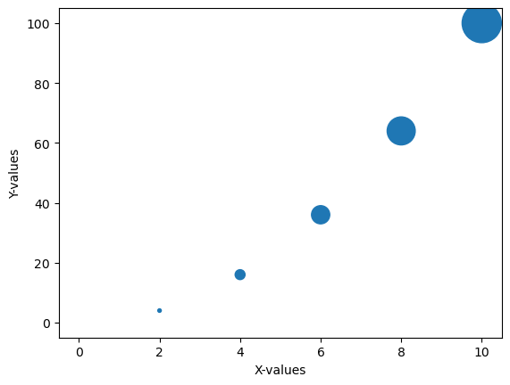

```python
x = np.array([0,2,4,6,8,10])
y = np.power(x, 2)
r = np.power(x, 3)
plt.scatter(x, y, s=r)
plt.xlabel('X-values'); plt.ylabel('Y-values');
```

## Visualizing Monte Carlo Pi

Using our previously discussed Monte Carlo method for determining $\pi$, we can visualize this procedure in a few different ways.

First, we can make a scatter plot of one determination of Pi and show how the algorithm works. X and Y values are generated with a uniform random distribution and any which fall inside the shaded region (where `x^2 + y^2 <= 1`) are counted.

```
(0.0, 1.0)
```

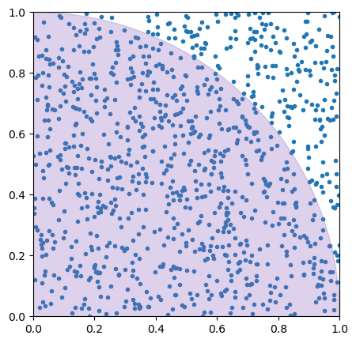

```python
plt.figure(figsize=(5,5))
ax = plt.gca()
circle = plt.Circle((0,0), radius=1, color='C4', alpha=0.3)

num_trials = 1000
x = np.random.uniform(low=0.0, high=1.0, size=num_trials)
y = np.random.uniform(low=0.0, high=1.0, size=num_trials)

plt.scatter(x,y,marker='.')
ax.add_patch(circle)
plt.ylim(0,1)
plt.xlim(0,1)
```

Next, we can plot the evolution of our MC-generated value of $\pi$ as we increase the number of samples:

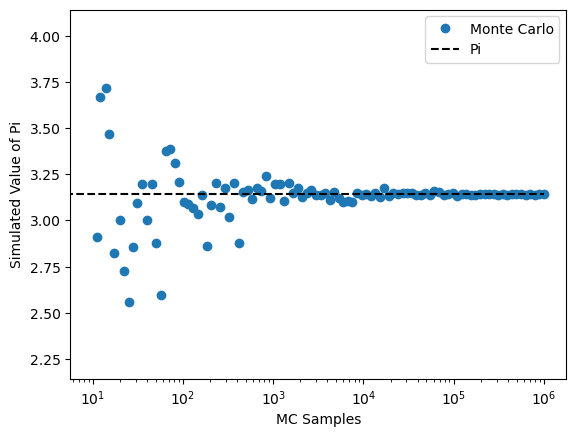

```python
mc_pi_samples = np.logspace(start=1, stop=6, num=100, dtype='int')
mc_pi_values = [mc_pi(x) for x in mc_pi_samples]

plt.plot(mc_pi_samples, mc_pi_values, marker='o', linestyle='None', label='Monte Carlo')
plt.ylim(np.pi-1,np.pi+1)
plt.hlines(np.pi, xmin=0,xmax=np.max(mc_pi_samples), color='k', linestyle='--', label='Pi')
plt.xscale('log');
plt.legend()
plt.xlabel('MC Samples');
plt.ylabel('Simulated Value of Pi')
```

## Histograms

Combining `numpy` and `matplotlib` we can begin to generate some of the key plots that are used to display data. One of the most common types of data visualizations are histograms.

To get started, let's generate some random data using `numpy.random`:

```python
a = np.random.uniform(low=0, high=10, size=100000)
b = np.random.exponential(scale=1, size=100000)
```

Now we can create a histogram (tabulation of values into discrete bins)

```python
h, bins = np.histogram(a, bins=20, range=(0,10))
```

and plot the distributions using `matplotlib`:

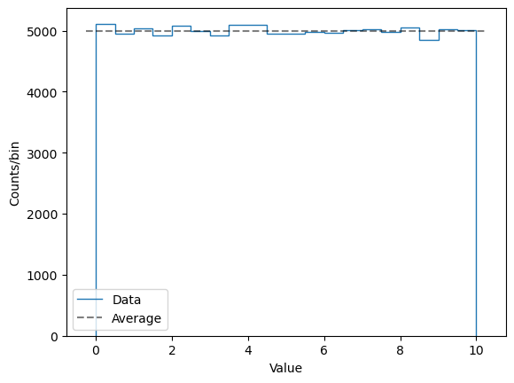

```python
plt.stairs(h, bins, label='Data')
plt.hlines(h.mean(), xmin=-0.25,xmax=10.25,linestyles='--', color='k', alpha=0.5, label='Average')
plt.xlabel('Value'); plt.ylabel('Counts/bin')
plt.legend(loc=3)
```

We can do the same to plot our exponential distribution of data, but this time we can set the y-scale to be `log` to better highlight the distribution:

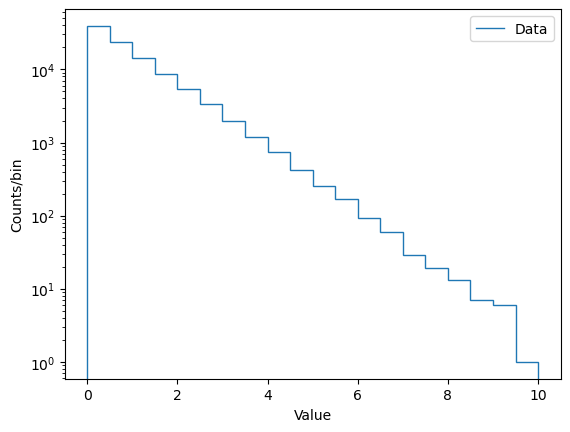

```python
h, bins = np.histogram(b, bins=20, range=(0,10))
plt.stairs(h, bins, label='Data')
plt.xlabel('Value'); plt.ylabel('Counts/bin'); plt.yscale('log')
plt.legend(loc=0)
```

## Data Processing with `Numpy`

Now that we have a basic familiarity with `numpy`, we will attempt to process some low-level data produced by a PMT connected to a scintillator cell.

Set the path to the data file and specify the trigger event properties.

```python
from pathlib import Path

data_file = '180822-EJ309-1700V-Cf252.dat'

HEADER_SIZE = 4
WINDOW_SIZE = 300

data_file_path = Path.cwd().parent.joinpath('data', data_file)
```

Get header from the beginning of the file and first event trace.

```python
header = np.fromfile(data_file_path, dtype=np.uint32,
                     count=HEADER_SIZE)

# Since each header item is 1 long-word (4 bytes)
# The data for 1st event begins 4 * HEADER_SIZE from the beginning of file
trace = np.fromfile(data_file_path, dtype=np.uint16,
                    count=WINDOW_SIZE, offset=HEADER_SIZE*4)
```

Plot the first trigger event trace.

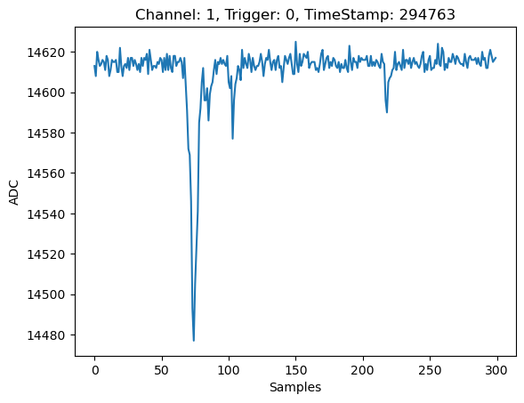

```python
plt.title(f"Channel: {header[1]}, Trigger: {header[2]}, TimeStamp: {header[3]}")
plt.plot(trace)
plt.xlabel('Samples');plt.ylabel('ADC');
```

Remove baseline counts

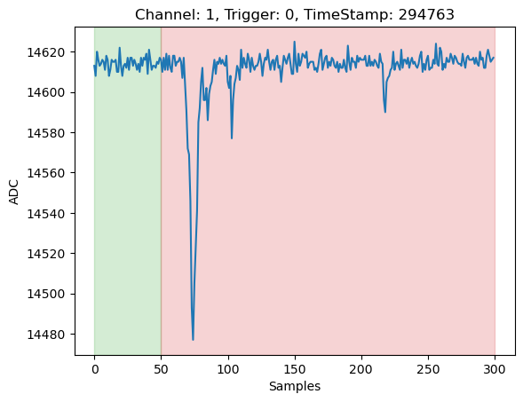

```python
plt.title(f"Channel: {header[1]}, Trigger: {header[2]}, TimeStamp: {header[3]}")
plt.plot(trace)
plt.axvspan(xmin=0,xmax=50, color='C2',alpha=0.2)
plt.axvspan(xmin=50,xmax=300, color='C3',alpha=0.2)
plt.xlabel('Samples'); plt.ylabel('ADC');
```

```python
baseline = np.average(trace[0:50])
print(f"baseline: {baseline:0.2f}ADC")
```

```
baseline: 14614.12ADC
```

Subtract the baseline value from all the elments of the `trace` array.

```python
trace = np.subtract(trace, baseline)
```

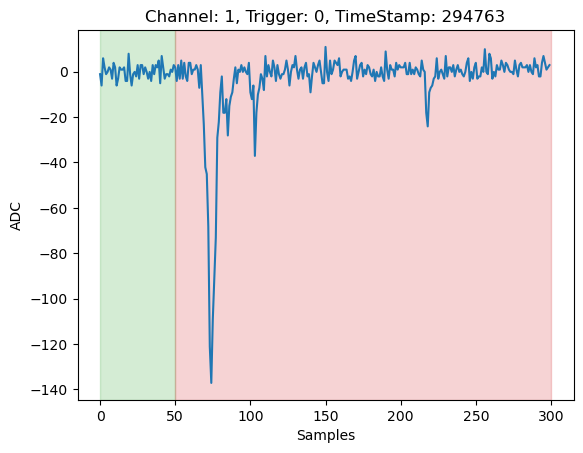

```python
plt.title(f"Channel: {header[1]}, Trigger: {header[2]}, TimeStamp: {header[3]}")
plt.plot(trace)
plt.axvspan(xmin=0,xmax=50, color='C2',alpha=0.2)
plt.axvspan(xmin=50,xmax=300, color='C3',alpha=0.2)
plt.xlabel('Samples');plt.ylabel('ADC');
```

Calculate the signal integral for the trigger event.

```python
sig_int = -np.sum(trace)
print(f"signal integral: {sig_int:.2f}ADC counts")
```

```
signal integral: 913.00ADC counts
```

### Analysis Function

```python
def data_reader(file_path, header_size=4, window_size=300, num_ev=10000):

    with file_path.open(mode='r') as d:
        # define data structure
        dtype = [('time_stamp','f4'), ('en','f4'), ('psd', 'f4')]
        data = np.zeros(shape=num_ev, dtype=dtype)

        for i in range(num_ev):
            header = np.fromfile(d, dtype=np.uint32, count=header_size)
            data['time_stamp'][i] = header[3]
            trace = np.fromfile(d, dtype=np.uint16, count=window_size)

            # Average the first 30 samples to determine what "zero" is
            bl = np.average(trace[0:30])

            # Subtract off the baseline
            trace = np.subtract(trace, bl)

            # find the minimum of the pulse
            peak_loc = np.argmin(trace)

            # Integrate the full pulse
            data['en'][i] = -np.sum(trace[peak_loc-30:peak_loc+100])

            # Integrate the tail of the pulse, then take the ratio to the full
            data['psd'][i] = -np.sum(trace[peak_loc+10:peak_loc+100])
            data['psd'][i] /= data['en'][i]

    return data
```

```python
data = data_reader(data_file_path,
                   header_size=HEADER_SIZE,
                   window_size=WINDOW_SIZE,
                   num_ev=50000)
```

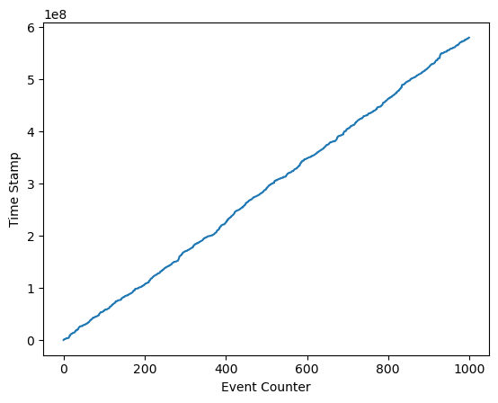

```python
plt.plot(data['time_stamp'][0:1000], marker=',')
plt.xlabel('Event Counter');
plt.ylabel('Time Stamp');
```

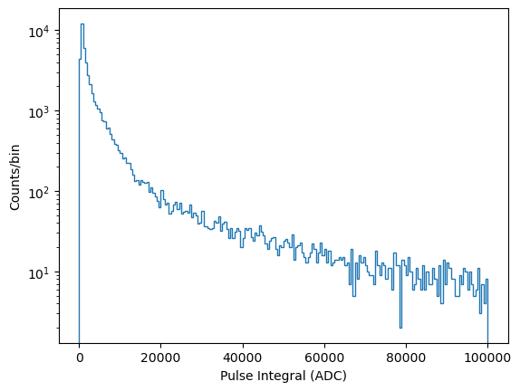

```python
h, bins = np.histogram(data['en'], bins=200, range=(0,100000))

plt.stairs(h, bins)
plt.yscale('log');
plt.xlabel('Pulse Integral (ADC)');
plt.ylabel('Counts/bin');
```

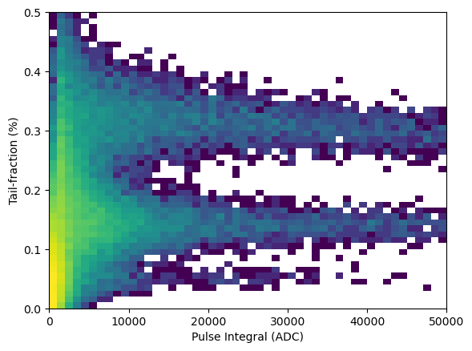

```python
plt.hist2d(data['en'], data['psd'], bins=50, range=((0,50000),(0,0.5)), norm=LogNorm());
plt.xlabel('Pulse Integral (ADC)');
plt.ylabel('Tail-fraction (%)');
```

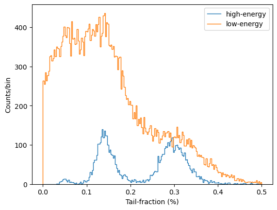

```python
filter = data['en']>15000
h, bins = np.histogram(data['psd'][filter], bins=200, range=(0,0.5))
plt.stairs(h, bins, label='high-energy');

filter = data['en']<15000
h, bins = np.histogram(data['psd'][filter], bins=200, range=(0,0.5))
plt.stairs(h, bins, label='low-energy');

plt.xlabel('Tail-fraction (%)');plt.ylabel('Counts/bin'); plt.legend();
```

## Aside: Data Preparation with `Pandas`

The `pandas` library builds on top of `numpy`. It excels at processing tabular data of heterogenous types.

This example deals with an Excel worksheet used to track project activities.

- It uses multiple rows to denote column headings.
- It comprises columns of data type `string` and `float`.
- The data must be prepared so that it maps cleanly to the fields of a relational database.

Load the necessary modules

```python
import numpy as np
import pandas as pd
from pathlib import Path
```

Load the Excel worksheet into a data frame

```python
data_file = '02-VA BMTv3 20220225.xlsx'
worksheet_name = 'OUTPUT'

data_file_path = Path.cwd().parent.joinpath('data', data_file)
df = pd.read_excel(data_file_path, sheet_name=worksheet_name, header=[0, 1, 2])
```

```python
df
```

|  | INDEX VALUE Unnamed: 0_level_1 Unnamed: 0_level_2 | Priority Unnamed: 1_level_1 Unnamed: 1_level_2 | Team Unnamed: 2_level_1 Unnamed: 2_level_2 | Project Mgr. Unnamed: 3_level_1 Unnamed: 3_level_2 | Building Code Unnamed: 4_level_1 Unnamed: 4_level_2 | Building ID Unnamed: 5_level_1 Unnamed: 5_level_2 | Building Description Unnamed: 6_level_1 Unnamed: 6_level_2 | Cluster # Unnamed: 7_level_1 Unnamed: 7_level_2 | # closets Unnamed: 8_level_1 Unnamed: 8_level_2 | Legacy Switch Count Unnamed: 9_level_1 Unnamed: 9_level_2 | ... | Building Transitions Building Transitions Healthcare_VN 33 | Building Transitions Building Transitions Voice_VN 34 | Building Transitions Building Transitions PCI_VN 35 | Building Transitions Building Transitions Building Communication Wired 36 | Building Transitions Building Transitions Full Building Wired Network Services Cutover to NGN 37 | Building Transitions Building Transitions Building Comms Wireless 38 | Building Transitions Building Transitions Wireless Cutover to NGN 39 | Building Transitions Building Transitions Legacy Cable & Equipment Removal 40 | Building Transitions Building Transitions Building Comms Completion 41 | Building Transitions Building Transitions Lessons Learned 42 |
| --- | --- | --- | --- | --- | --- | --- | --- | --- | --- | --- | --- | --- | --- | --- | --- | --- | --- | --- | --- | --- | --- |
| 0 | 1.0 | 1.0 | NaN | NaN | VAMC-01 | 4160 | VA MEDICAL CTR BLDG 01 | C02-02 MDF | 9 | NaN | ... | 0.0 | 0.0 | 0.0 | 0.0 | 0.0 | 0.0 | 0.0 | 0.0 | 0.0 | 0.0 |
| 1 | 2.0 | 2.0 | NaN | NaN | VAMC-02 | 4161 | VA MEDICAL CTR BLDG 02 | C02-02 | 4 | NaN | ... | 0.0 | 0.0 | 0.0 | 0.0 | 0.0 | 0.0 | 0.0 | 0.0 | 0.0 | 0.0 |
| 2 | 3.0 | 3.0 | NaN | NaN | VAMC-03 | 41?? | VA MEDICAL CTR BLDG 03 | C02-01 | 1 | NaN | ... | 0.0 | 0.0 | 0.0 | 0.0 | 0.0 | 0.0 | 0.0 | 0.0 | 0.0 | 0.0 |
| 3 | 4.0 | 4.0 | NaN | NaN | VAMC-04 | 4162 | VA MEDICAL CTR BLDG 04 | C02-01 | 1 | NaN | ... | 0.0 | 0.0 | 0.0 | 0.0 | 0.0 | 0.0 | 0.0 | 0.0 | 0.0 | 0.0 |
| 4 | 5.0 | 5.0 | NaN | NaN | VAMC-05 | 4164 | VA MEDICAL CTR BLDG 05 | C02-01 MDF | 4 | NaN | ... | 0.0 | 0.0 | 0.0 | 0.0 | 0.0 | 0.0 | 0.0 | 0.0 | 0.0 | 0.0 |
| 5 | 6.0 | 6.0 | NaN | NaN | VAMC-08 | 41?? | VA MEDICAL CTR BLDG 08 | C02-01 | 1 | NaN | ... | 0.0 | 0.0 | 0.0 | 0.0 | 0.0 | 0.0 | 0.0 | 0.0 | 0.0 | 0.0 |
| 6 | 7.0 | 7.0 | NaN | NaN | VAMC-08.5 | 41?? | VA MEDICAL CTR BLDG 08.5 | C02-01 | 1 | NaN | ... | 0.0 | 0.0 | 0.0 | 0.0 | 0.0 | 0.0 | 0.0 | 0.0 | 0.0 | 0.0 |
| 7 | 8.0 | 8.0 | NaN | NaN | VAMC-12A | 41?? | VA MEDICAL CTR BLDG 12A | C02-01 | 1 | NaN | ... | 0.0 | 0.0 | 0.0 | 0.0 | 0.0 | 0.0 | 0.0 | 0.0 | 0.0 | 0.0 |
| 8 | 9.0 | 9.0 | NaN | NaN | VAMC-34 | 4020 | VA MEDICAL CTR BLDG 34 | C02-01 | 1 | NaN | ... | 0.0 | 0.0 | 0.0 | 0.0 | 0.0 | 0.0 | 0.0 | 0.0 | 0.0 | 0.0 |
| 9 | 10.0 | 10.0 | NaN | NaN | VAMC-35 | 41?? | VA MEDICAL CTR BLDG 35 | C02-01 | 2 | NaN | ... | 0.0 | 0.0 | 0.0 | 0.0 | 0.0 | 0.0 | 0.0 | 0.0 | 0.0 | 0.0 |
| 10 | 11.0 | 11.0 | NaN | NaN | VAMC-35A | 4165 | VA MEDICAL CTR BLDG 35A | C02-01 | 2 | NaN | ... | 0.0 | 0.0 | 0.0 | 0.0 | 0.0 | 0.0 | 0.0 | 0.0 | 0.0 | 0.0 |
| 11 | 12.0 | 12.0 | NaN | NaN | VAMC-36 | 41?? | VA MEDICAL CTR BLDG 36 | C02-01 | 1 | NaN | ... | 0.0 | 0.0 | 0.0 | 0.0 | 0.0 | 0.0 | 0.0 | 0.0 | 0.0 | 0.0 |
| 12 | NaN | NaN | NaN | NaN | NaN | NaN | NaN | NaN | 28 | 0.0 | ... | 0.0 | 0.0 | 0.0 | 0.0 | 0.0 | 0.0 | 0.0 | 0.0 | 0.0 | 0.0 |
| 13 | NaN | NaN | NaN | NaN | NaN | NaN | NaN | NaN | NaN | NaN | ... | NaN | NaN | NaN | NaN | NaN | NaN | NaN | NaN | NaN | NaN |
| 14 | NaN | NaN | NaN | NaN | NaN | NaN | NaN | NaN | NaN | NaN | ... | NaN | NaN | NaN | NaN | NaN | NaN | NaN | NaN | NaN | NaN |
| 15 | NaN | NaN | NaN | NaN | NaN | NaN | NaN | NaN |  | NaN | ... | NaN | NaN | NaN | NaN | NaN | NaN | NaN | NaN | NaN | NaN |
| 16 | NaN | NaN | NaN | NaN | NaN | NaN | NaN | NaN | NaN | NaN | ... | NaN | NaN | NaN | NaN | NaN | NaN | NaN | NaN | NaN | NaN |
| 17 | NaN | NaN | NaN | NaN | NaN | NaN | NaN | NaN | NaN | NaN | ... | NaN | NaN | NaN | NaN | NaN | NaN | NaN | NaN | NaN | NaN |
| 18 | NaN | NaN | NaN | NaN | NaN | NaN | NaN | NaN | NaN | NaN | ... | NaN | NaN | NaN | NaN | NaN | NaN | NaN | NaN | NaN | NaN |
| 19 | NaN | NaN | NaN | NaN | NaN | NaN | NaN | NaN | NaN | NaN | ... | NaN | NaN | NaN | NaN | 12.0 | NaN | NaN | NaN | NaN | NaN |
| 20 | NaN | NaN | NaN | NaN | NaN | NaN | NaN | NaN | NaN | NaN | ... | NaN | NaN | NaN | NaN | 0.0 | NaN | NaN | NaN | NaN | NaN |
| 21 | NaN | NaN | NaN | NaN | NaN | NaN | NaN | NaN | NaN | NaN | ... | NaN | NaN | NaN | NaN | 0.0 | NaN | NaN | NaN | NaN | NaN |
| 22 | NaN | NaN | NaN | NaN | NaN | NaN | NaN | NaN | NaN | NaN | ... | NaN | NaN | NaN | NaN | 0.0 | NaN | NaN | NaN | NaN | NaN |
| 23 | NaN | NaN | NaN | NaN | NaN | NaN | NaN | NaN | NaN | NaN | ... | NaN | NaN | NaN | NaN | 0.0 | NaN | NaN | NaN | NaN | NaN |
| 24 | NaN | NaN | NaN | NaN | NaN | NaN | NaN | NaN | NaN | NaN | ... | NaN | NaN | NaN | NaN | 0.0 | NaN | NaN | NaN | NaN | NaN |
| 25 | NaN | NaN | NaN | NaN | NaN | NaN | NaN | NaN | NaN | NaN | ... | NaN | NaN | NaN | NaN | 0.0 | NaN | NaN | NaN | NaN | NaN |
| 26 | NaN | NaN | NaN | NaN | NaN | NaN | NaN | NaN | NaN | NaN | ... | NaN | NaN | NaN | NaN | 0.0 | NaN | NaN | NaN | NaN | NaN |
| 27 | NaN | NaN | NaN | NaN | NaN | NaN | NaN | NaN | NaN | NaN | ... | NaN | NaN | NaN | NaN | NaN | NaN | NaN | NaN | NaN | NaN |
| 28 | NaN | NaN | NaN | NaN | NaN | NaN | NaN | NaN | NaN | NaN | ... | NaN | NaN | NaN | NaN | 12.0 | NaN | NaN | NaN | NaN | NaN |

29 rows × 63 columns

```python
flattened_column_names = [
    (l1 if ('Unnamed:' in l2) else l2 ) for l1, l2, l3 in df.columns]
```

```python
flattened_column_names
```

```
['INDEX VALUE',
 'Priority',
 'Team',
 'Project Mgr.',
 'Building Code',
 'Building ID',
 'Building Description',
 'Cluster #',
 '# closets',
 'Legacy Switch Count',
 'NGN Switch Count',
 "AP's",
 'Assigned General Building VN',
 'Cutover Type',
 'Known special use networks in building',
 'Fabric Site Designation',
 'Wired Migration Date\n(tentative)',
 'Wireless Migration Date',
 'STAGE 1',
 'STAGE 2/3',
 'Building',
 'Program and Building Communication',
 'Switch Discovery',
 'Extension Discovery & Design',
 'Inter-Fiber Discovery & Deployment',
 'Building Comms Closet Communication',
 'Closet Surveys',
 'Bldg/Clstr -InterConnected Design',
 'IP Discovery',
 'Speciality VN Device Discovery',
 'Firewall Review',
 'WAP Predictive Review',
 'Business Questionnaire',
 'Building Comms DDNS Awareness',
 'DDNS',
 'IP, AV, & Printer Remediation',
 'Walkthrough & Intrabuilding Architecture Design',
 'BOM Process',
 'Closet Remediation',
 'Switch Hardware Staging',
```

[output cut: 8 more lines]

```
 'Specialty Devices to NGN',
 'User Specific Testing',
 'Safety_VN',
 'BLDGSYS_VN',
 'ScienceNet to NGN',
 'Healthcare_VN',
 'Voice_VN',
 'PCI_VN',
 'Building Communication Wired ',
 'Full Building Wired Network Services Cutover to NGN',
 'Building Comms Wireless ',
 'Wireless Cutover to NGN',
 'Legacy Cable & Equipment Removal',
 'Building Comms Completion',
 'Lessons Learned']
```

Rename the data frame columns with the `flattened_column_names`

```python
df.columns = flattened_column_names
```

```python
df
```

|  | INDEX VALUE | Priority | Team | Project Mgr. | Building Code | Building ID | Building Description | Cluster # | # closets | Legacy Switch Count | ... | Healthcare_VN | Voice_VN | PCI_VN | Building Communication Wired | Full Building Wired Network Services Cutover to NGN | Building Comms Wireless | Wireless Cutover to NGN | Legacy Cable & Equipment Removal | Building Comms Completion | Lessons Learned |
| --- | --- | --- | --- | --- | --- | --- | --- | --- | --- | --- | --- | --- | --- | --- | --- | --- | --- | --- | --- | --- | --- |
| 0 | 1.0 | 1.0 | NaN | NaN | VAMC-01 | 4160 | VA MEDICAL CTR BLDG 01 | C02-02 MDF | 9 | NaN | ... | 0.0 | 0.0 | 0.0 | 0.0 | 0.0 | 0.0 | 0.0 | 0.0 | 0.0 | 0.0 |
| 1 | 2.0 | 2.0 | NaN | NaN | VAMC-02 | 4161 | VA MEDICAL CTR BLDG 02 | C02-02 | 4 | NaN | ... | 0.0 | 0.0 | 0.0 | 0.0 | 0.0 | 0.0 | 0.0 | 0.0 | 0.0 | 0.0 |
| 2 | 3.0 | 3.0 | NaN | NaN | VAMC-03 | 41?? | VA MEDICAL CTR BLDG 03 | C02-01 | 1 | NaN | ... | 0.0 | 0.0 | 0.0 | 0.0 | 0.0 | 0.0 | 0.0 | 0.0 | 0.0 | 0.0 |
| 3 | 4.0 | 4.0 | NaN | NaN | VAMC-04 | 4162 | VA MEDICAL CTR BLDG 04 | C02-01 | 1 | NaN | ... | 0.0 | 0.0 | 0.0 | 0.0 | 0.0 | 0.0 | 0.0 | 0.0 | 0.0 | 0.0 |
| 4 | 5.0 | 5.0 | NaN | NaN | VAMC-05 | 4164 | VA MEDICAL CTR BLDG 05 | C02-01 MDF | 4 | NaN | ... | 0.0 | 0.0 | 0.0 | 0.0 | 0.0 | 0.0 | 0.0 | 0.0 | 0.0 | 0.0 |
| 5 | 6.0 | 6.0 | NaN | NaN | VAMC-08 | 41?? | VA MEDICAL CTR BLDG 08 | C02-01 | 1 | NaN | ... | 0.0 | 0.0 | 0.0 | 0.0 | 0.0 | 0.0 | 0.0 | 0.0 | 0.0 | 0.0 |
| 6 | 7.0 | 7.0 | NaN | NaN | VAMC-08.5 | 41?? | VA MEDICAL CTR BLDG 08.5 | C02-01 | 1 | NaN | ... | 0.0 | 0.0 | 0.0 | 0.0 | 0.0 | 0.0 | 0.0 | 0.0 | 0.0 | 0.0 |
| 7 | 8.0 | 8.0 | NaN | NaN | VAMC-12A | 41?? | VA MEDICAL CTR BLDG 12A | C02-01 | 1 | NaN | ... | 0.0 | 0.0 | 0.0 | 0.0 | 0.0 | 0.0 | 0.0 | 0.0 | 0.0 | 0.0 |
| 8 | 9.0 | 9.0 | NaN | NaN | VAMC-34 | 4020 | VA MEDICAL CTR BLDG 34 | C02-01 | 1 | NaN | ... | 0.0 | 0.0 | 0.0 | 0.0 | 0.0 | 0.0 | 0.0 | 0.0 | 0.0 | 0.0 |
| 9 | 10.0 | 10.0 | NaN | NaN | VAMC-35 | 41?? | VA MEDICAL CTR BLDG 35 | C02-01 | 2 | NaN | ... | 0.0 | 0.0 | 0.0 | 0.0 | 0.0 | 0.0 | 0.0 | 0.0 | 0.0 | 0.0 |
| 10 | 11.0 | 11.0 | NaN | NaN | VAMC-35A | 4165 | VA MEDICAL CTR BLDG 35A | C02-01 | 2 | NaN | ... | 0.0 | 0.0 | 0.0 | 0.0 | 0.0 | 0.0 | 0.0 | 0.0 | 0.0 | 0.0 |
| 11 | 12.0 | 12.0 | NaN | NaN | VAMC-36 | 41?? | VA MEDICAL CTR BLDG 36 | C02-01 | 1 | NaN | ... | 0.0 | 0.0 | 0.0 | 0.0 | 0.0 | 0.0 | 0.0 | 0.0 | 0.0 | 0.0 |
| 12 | NaN | NaN | NaN | NaN | NaN | NaN | NaN | NaN | 28 | 0.0 | ... | 0.0 | 0.0 | 0.0 | 0.0 | 0.0 | 0.0 | 0.0 | 0.0 | 0.0 | 0.0 |
| 13 | NaN | NaN | NaN | NaN | NaN | NaN | NaN | NaN | NaN | NaN | ... | NaN | NaN | NaN | NaN | NaN | NaN | NaN | NaN | NaN | NaN |
| 14 | NaN | NaN | NaN | NaN | NaN | NaN | NaN | NaN | NaN | NaN | ... | NaN | NaN | NaN | NaN | NaN | NaN | NaN | NaN | NaN | NaN |
| 15 | NaN | NaN | NaN | NaN | NaN | NaN | NaN | NaN |  | NaN | ... | NaN | NaN | NaN | NaN | NaN | NaN | NaN | NaN | NaN | NaN |
| 16 | NaN | NaN | NaN | NaN | NaN | NaN | NaN | NaN | NaN | NaN | ... | NaN | NaN | NaN | NaN | NaN | NaN | NaN | NaN | NaN | NaN |
| 17 | NaN | NaN | NaN | NaN | NaN | NaN | NaN | NaN | NaN | NaN | ... | NaN | NaN | NaN | NaN | NaN | NaN | NaN | NaN | NaN | NaN |
| 18 | NaN | NaN | NaN | NaN | NaN | NaN | NaN | NaN | NaN | NaN | ... | NaN | NaN | NaN | NaN | NaN | NaN | NaN | NaN | NaN | NaN |
| 19 | NaN | NaN | NaN | NaN | NaN | NaN | NaN | NaN | NaN | NaN | ... | NaN | NaN | NaN | NaN | 12.0 | NaN | NaN | NaN | NaN | NaN |
| 20 | NaN | NaN | NaN | NaN | NaN | NaN | NaN | NaN | NaN | NaN | ... | NaN | NaN | NaN | NaN | 0.0 | NaN | NaN | NaN | NaN | NaN |
| 21 | NaN | NaN | NaN | NaN | NaN | NaN | NaN | NaN | NaN | NaN | ... | NaN | NaN | NaN | NaN | 0.0 | NaN | NaN | NaN | NaN | NaN |
| 22 | NaN | NaN | NaN | NaN | NaN | NaN | NaN | NaN | NaN | NaN | ... | NaN | NaN | NaN | NaN | 0.0 | NaN | NaN | NaN | NaN | NaN |
| 23 | NaN | NaN | NaN | NaN | NaN | NaN | NaN | NaN | NaN | NaN | ... | NaN | NaN | NaN | NaN | 0.0 | NaN | NaN | NaN | NaN | NaN |
| 24 | NaN | NaN | NaN | NaN | NaN | NaN | NaN | NaN | NaN | NaN | ... | NaN | NaN | NaN | NaN | 0.0 | NaN | NaN | NaN | NaN | NaN |
| 25 | NaN | NaN | NaN | NaN | NaN | NaN | NaN | NaN | NaN | NaN | ... | NaN | NaN | NaN | NaN | 0.0 | NaN | NaN | NaN | NaN | NaN |
| 26 | NaN | NaN | NaN | NaN | NaN | NaN | NaN | NaN | NaN | NaN | ... | NaN | NaN | NaN | NaN | 0.0 | NaN | NaN | NaN | NaN | NaN |
| 27 | NaN | NaN | NaN | NaN | NaN | NaN | NaN | NaN | NaN | NaN | ... | NaN | NaN | NaN | NaN | NaN | NaN | NaN | NaN | NaN | NaN |
| 28 | NaN | NaN | NaN | NaN | NaN | NaN | NaN | NaN | NaN | NaN | ... | NaN | NaN | NaN | NaN | 12.0 | NaN | NaN | NaN | NaN | NaN |

29 rows × 63 columns

The column names should be converted the names of the fields used by the relational database.

```python
sql_table_fields = [
    'index',
    'priority',
    'team',
    'project_manager',
    'building_code',
    'building_id',
    'building_description',
    'cluster_number',
    'number_closets',
    'legacy_switch_count',
    'ngn_switch_count',
    'aps',
    'assigned_building_vn',
    'cutover_type',
    'known_special_networks',
    'fabric_site_designation',
    'wired_migration_date',
    'wireless_migration_date',
    'stage_1_complete',
    'stage_2_3_complete',
    'building_complete',
    'program_building_communication',
    'switch_discovery',
    'extension_discovery',
    'inter_fiber',
    'building_coms_closet',
    'closet_surveys',
    'bldg_clstr_design',
    'ip_discovery',
    'speciality_vn',
    'firewall_review',
    'wap_predictive_review',
    'business_questionnaire',
    'building_comms_ddns',
    'ddns',
    'ip_av_printer_remediation',
    'walkthrough_intrabuilding',
    'bom_process',
    'closet_remediation',
    'switch_hardware_staging',
    'logistics',
    'switch_rack_stack',
    'lan_automation',
    'building_comms',
    'wap_prep',
    'qa_testing',
    'printers_ngn',
    'building_comms_app_testing',
    'specialty_devices',
    'user_specific_testing',
    'safety_vn',
    'bldgsys_vn',
    'sciencenet_ngn',
    'healthcare_vn',
    'voice_vn',
    'pci_vn',
    'building_comms_wired',
    'full_building_wired_cutover_ngn',
    'building_comms_wireless',
    'wireless_cutover_ngn',
    'legacy_cable_removal',
    'building_comms_completion',
    'lessons_learned']
```

Construct a lookup dictionary of `flattened_column_names` to `sql_table_fields`

```python
rename_map = dict(zip(flattened_column_names, sql_table_fields))
```

```python
rename_map
```

```
{'INDEX VALUE': 'index',
 'Priority': 'priority',
 'Team': 'team',
 'Project Mgr.': 'project_manager',
 'Building Code': 'building_code',
 'Building ID': 'building_id',
 'Building Description': 'building_description',
 'Cluster #': 'cluster_number',
 '# closets': 'number_closets',
 'Legacy Switch Count': 'legacy_switch_count',
 'NGN Switch Count': 'ngn_switch_count',
 "AP's": 'aps',
 'Assigned General Building VN': 'assigned_building_vn',
 'Cutover Type': 'cutover_type',
 'Known special use networks in building': 'known_special_networks',
 'Fabric Site Designation': 'fabric_site_designation',
 'Wired Migration Date\n(tentative)': 'wired_migration_date',
 'Wireless Migration Date': 'wireless_migration_date',
 'STAGE 1': 'stage_1_complete',
 'STAGE 2/3': 'stage_2_3_complete',
 'Building': 'building_complete',
 'Program and Building Communication': 'program_building_communication',
 'Switch Discovery': 'switch_discovery',
 'Extension Discovery & Design': 'extension_discovery',
 'Inter-Fiber Discovery & Deployment': 'inter_fiber',
 'Building Comms Closet Communication': 'building_coms_closet',
 'Closet Surveys': 'closet_surveys',
 'Bldg/Clstr -InterConnected Design': 'bldg_clstr_design',
 'IP Discovery': 'ip_discovery',
 'Speciality VN Device Discovery': 'speciality_vn',
 'Firewall Review': 'firewall_review',
 'WAP Predictive Review': 'wap_predictive_review',
 'Business Questionnaire': 'business_questionnaire',
 'Building Comms DDNS Awareness': 'building_comms_ddns',
 'DDNS': 'ddns',
 'IP, AV, & Printer Remediation': 'ip_av_printer_remediation',
 'Walkthrough & Intrabuilding Architecture Design': 'walkthrough_intrabuilding',
 'BOM Process': 'bom_process',
 'Closet Remediation': 'closet_remediation',
 'Switch Hardware Staging': 'switch_hardware_staging',
```

[output cut: 8 more lines]

```
 'Specialty Devices to NGN': 'specialty_devices',
 'User Specific Testing': 'user_specific_testing',
 'Safety_VN': 'safety_vn',
 'BLDGSYS_VN': 'bldgsys_vn',
 'ScienceNet to NGN': 'sciencenet_ngn',
 'Healthcare_VN': 'healthcare_vn',
 'Voice_VN': 'voice_vn',
 'PCI_VN': 'pci_vn',
 'Building Communication Wired ': 'building_comms_wired',
 'Full Building Wired Network Services Cutover to NGN': 'full_building_wired_cutover_ngn',
 'Building Comms Wireless ': 'building_comms_wireless',
 'Wireless Cutover to NGN': 'wireless_cutover_ngn',
 'Legacy Cable & Equipment Removal': 'legacy_cable_removal',
 'Building Comms Completion': 'building_comms_completion',
 'Lessons Learned': 'lessons_learned'}
```

Rename the dataframe fields

```python
df.rename(columns=rename_map, inplace=True)
```

```python
df
```

|  | index | priority | team | project_manager | building_code | building_id | building_description | cluster_number | number_closets | legacy_switch_count | ... | healthcare_vn | voice_vn | pci_vn | building_comms_wired | full_building_wired_cutover_ngn | building_comms_wireless | wireless_cutover_ngn | legacy_cable_removal | building_comms_completion | lessons_learned |
| --- | --- | --- | --- | --- | --- | --- | --- | --- | --- | --- | --- | --- | --- | --- | --- | --- | --- | --- | --- | --- | --- |
| 0 | 1.0 | 1.0 | NaN | NaN | VAMC-01 | 4160 | VA MEDICAL CTR BLDG 01 | C02-02 MDF | 9 | NaN | ... | 0.0 | 0.0 | 0.0 | 0.0 | 0.0 | 0.0 | 0.0 | 0.0 | 0.0 | 0.0 |
| 1 | 2.0 | 2.0 | NaN | NaN | VAMC-02 | 4161 | VA MEDICAL CTR BLDG 02 | C02-02 | 4 | NaN | ... | 0.0 | 0.0 | 0.0 | 0.0 | 0.0 | 0.0 | 0.0 | 0.0 | 0.0 | 0.0 |
| 2 | 3.0 | 3.0 | NaN | NaN | VAMC-03 | 41?? | VA MEDICAL CTR BLDG 03 | C02-01 | 1 | NaN | ... | 0.0 | 0.0 | 0.0 | 0.0 | 0.0 | 0.0 | 0.0 | 0.0 | 0.0 | 0.0 |
| 3 | 4.0 | 4.0 | NaN | NaN | VAMC-04 | 4162 | VA MEDICAL CTR BLDG 04 | C02-01 | 1 | NaN | ... | 0.0 | 0.0 | 0.0 | 0.0 | 0.0 | 0.0 | 0.0 | 0.0 | 0.0 | 0.0 |
| 4 | 5.0 | 5.0 | NaN | NaN | VAMC-05 | 4164 | VA MEDICAL CTR BLDG 05 | C02-01 MDF | 4 | NaN | ... | 0.0 | 0.0 | 0.0 | 0.0 | 0.0 | 0.0 | 0.0 | 0.0 | 0.0 | 0.0 |
| 5 | 6.0 | 6.0 | NaN | NaN | VAMC-08 | 41?? | VA MEDICAL CTR BLDG 08 | C02-01 | 1 | NaN | ... | 0.0 | 0.0 | 0.0 | 0.0 | 0.0 | 0.0 | 0.0 | 0.0 | 0.0 | 0.0 |
| 6 | 7.0 | 7.0 | NaN | NaN | VAMC-08.5 | 41?? | VA MEDICAL CTR BLDG 08.5 | C02-01 | 1 | NaN | ... | 0.0 | 0.0 | 0.0 | 0.0 | 0.0 | 0.0 | 0.0 | 0.0 | 0.0 | 0.0 |
| 7 | 8.0 | 8.0 | NaN | NaN | VAMC-12A | 41?? | VA MEDICAL CTR BLDG 12A | C02-01 | 1 | NaN | ... | 0.0 | 0.0 | 0.0 | 0.0 | 0.0 | 0.0 | 0.0 | 0.0 | 0.0 | 0.0 |
| 8 | 9.0 | 9.0 | NaN | NaN | VAMC-34 | 4020 | VA MEDICAL CTR BLDG 34 | C02-01 | 1 | NaN | ... | 0.0 | 0.0 | 0.0 | 0.0 | 0.0 | 0.0 | 0.0 | 0.0 | 0.0 | 0.0 |
| 9 | 10.0 | 10.0 | NaN | NaN | VAMC-35 | 41?? | VA MEDICAL CTR BLDG 35 | C02-01 | 2 | NaN | ... | 0.0 | 0.0 | 0.0 | 0.0 | 0.0 | 0.0 | 0.0 | 0.0 | 0.0 | 0.0 |
| 10 | 11.0 | 11.0 | NaN | NaN | VAMC-35A | 4165 | VA MEDICAL CTR BLDG 35A | C02-01 | 2 | NaN | ... | 0.0 | 0.0 | 0.0 | 0.0 | 0.0 | 0.0 | 0.0 | 0.0 | 0.0 | 0.0 |
| 11 | 12.0 | 12.0 | NaN | NaN | VAMC-36 | 41?? | VA MEDICAL CTR BLDG 36 | C02-01 | 1 | NaN | ... | 0.0 | 0.0 | 0.0 | 0.0 | 0.0 | 0.0 | 0.0 | 0.0 | 0.0 | 0.0 |
| 12 | NaN | NaN | NaN | NaN | NaN | NaN | NaN | NaN | 28 | 0.0 | ... | 0.0 | 0.0 | 0.0 | 0.0 | 0.0 | 0.0 | 0.0 | 0.0 | 0.0 | 0.0 |
| 13 | NaN | NaN | NaN | NaN | NaN | NaN | NaN | NaN | NaN | NaN | ... | NaN | NaN | NaN | NaN | NaN | NaN | NaN | NaN | NaN | NaN |
| 14 | NaN | NaN | NaN | NaN | NaN | NaN | NaN | NaN | NaN | NaN | ... | NaN | NaN | NaN | NaN | NaN | NaN | NaN | NaN | NaN | NaN |
| 15 | NaN | NaN | NaN | NaN | NaN | NaN | NaN | NaN |  | NaN | ... | NaN | NaN | NaN | NaN | NaN | NaN | NaN | NaN | NaN | NaN |
| 16 | NaN | NaN | NaN | NaN | NaN | NaN | NaN | NaN | NaN | NaN | ... | NaN | NaN | NaN | NaN | NaN | NaN | NaN | NaN | NaN | NaN |
| 17 | NaN | NaN | NaN | NaN | NaN | NaN | NaN | NaN | NaN | NaN | ... | NaN | NaN | NaN | NaN | NaN | NaN | NaN | NaN | NaN | NaN |
| 18 | NaN | NaN | NaN | NaN | NaN | NaN | NaN | NaN | NaN | NaN | ... | NaN | NaN | NaN | NaN | NaN | NaN | NaN | NaN | NaN | NaN |
| 19 | NaN | NaN | NaN | NaN | NaN | NaN | NaN | NaN | NaN | NaN | ... | NaN | NaN | NaN | NaN | 12.0 | NaN | NaN | NaN | NaN | NaN |
| 20 | NaN | NaN | NaN | NaN | NaN | NaN | NaN | NaN | NaN | NaN | ... | NaN | NaN | NaN | NaN | 0.0 | NaN | NaN | NaN | NaN | NaN |
| 21 | NaN | NaN | NaN | NaN | NaN | NaN | NaN | NaN | NaN | NaN | ... | NaN | NaN | NaN | NaN | 0.0 | NaN | NaN | NaN | NaN | NaN |
| 22 | NaN | NaN | NaN | NaN | NaN | NaN | NaN | NaN | NaN | NaN | ... | NaN | NaN | NaN | NaN | 0.0 | NaN | NaN | NaN | NaN | NaN |
| 23 | NaN | NaN | NaN | NaN | NaN | NaN | NaN | NaN | NaN | NaN | ... | NaN | NaN | NaN | NaN | 0.0 | NaN | NaN | NaN | NaN | NaN |
| 24 | NaN | NaN | NaN | NaN | NaN | NaN | NaN | NaN | NaN | NaN | ... | NaN | NaN | NaN | NaN | 0.0 | NaN | NaN | NaN | NaN | NaN |
| 25 | NaN | NaN | NaN | NaN | NaN | NaN | NaN | NaN | NaN | NaN | ... | NaN | NaN | NaN | NaN | 0.0 | NaN | NaN | NaN | NaN | NaN |
| 26 | NaN | NaN | NaN | NaN | NaN | NaN | NaN | NaN | NaN | NaN | ... | NaN | NaN | NaN | NaN | 0.0 | NaN | NaN | NaN | NaN | NaN |
| 27 | NaN | NaN | NaN | NaN | NaN | NaN | NaN | NaN | NaN | NaN | ... | NaN | NaN | NaN | NaN | NaN | NaN | NaN | NaN | NaN | NaN |
| 28 | NaN | NaN | NaN | NaN | NaN | NaN | NaN | NaN | NaN | NaN | ... | NaN | NaN | NaN | NaN | 12.0 | NaN | NaN | NaN | NaN | NaN |

29 rows × 63 columns

## Further Cleanup

- Replace new line characters with a single space
- Remove rows that begin with `NaN`
- Remove index column; (Database will recreate on import to table)
- Add `archive_date column` with current date to note date of import into table
- Set data `string` data type for columns with strings and standardize string values
- Set columns that are not `string` to `float`

## Conclusion

- We've only scratched the surface of what python can do for data analysis.
- JupyterLab lends itself well to exploratory data analysis.
- Online Resources:
  - Numpy (https://numpy.org)
  - Matplotlib (https://matplotlib.org)
  - HEP-specific tools: SciKit-HEP (https://scikit-hep.org)
  - The repository for this tutorial: https://github.com/WrightLaboratory/data_analysis
  - Slides can be viewed here: https://wrightlaboratory.github.io/data_analysis/#/
  - Live notebook environment here: https://mybinder.org/v2/gh/WrightLaboratory/data_analysis/HEAD
- Further reading (O'Reilly Books available through Yale Library):
  - [Data Analysis with Python by Wes McKinney](https://learning.oreilly.com/library/view/python-for-data/9781491957653/)
  - [High Performance Python](https://learning.oreilly.com/library/view/high-performance-python/9781492055013/)